# C2 - Assignment 2.

Son Nam Nguyen

11/27/2021

## Access API

I have decided to scrape the TendersGuru public API, which contains procurement data of the countries situated in the Pannonian Basin along with Spain. Please, find the documentation on the API [here](https://tenders.guru/hu/api).

```r
#send GET request
res <- httr::GET(url = 'https://tenders.guru/api/hu/tenders')

#retrive JSON response and flatten out the object
t <- fromJSON(content(res, 'text'), flatten = T)

#convert it to dataframe
df <- data.frame(t$data)

df %>%
  select(-c("description", "awarded")) %>% #drop long text column for clarity
  head(5) %>%
  kbl() %>%
  kable_styling("striped") %>%
  scroll_box(width = "100%")
```

| id | date | deadline_date | title | category | phase | phase_en | place | sid | eid | awarded_value | awarded_currency | awarded_value_eur | deadline_length_days | indicators | purchaser.id | purchaser.sid | purchaser.name | type.id | type.name | type.slug |
| --- | --- | --- | --- | --- | --- | --- | --- | --- | --- | --- | --- | --- | --- | --- | --- | --- | --- | --- | --- | --- |
| 36077 | 2021-08-01 | 2021-08-12 | “Régészeti feltárásokhoz szükséges kézi földmunka” | constructions | E60 - Szerződéskötési-, teljesítési szakasz | Contracting and performance phase | HU MAGYARORSZÁG | EKR000835312021 | 8799438370123 | 299000000.00 | HUF | 819784.50 | NA | NULL | 4895 | 8.796421e+12 | Szent István Király Múzeum | 2 | 2 | 2 |
| 36073 | 2021-09-26 | 2021-10-07 | Cserepes és Szélmalom utcák felújítása | constructions | E60 - Szerződéskötési-, teljesítési szakasz | Contracting and performance phase | HU322 Jász-Nagykun-Szolnok | EKR001148352021 | 8799640974667 | 56147040.00 | HUF | 153941.38 | 11 | NULL | 118 | 8.796605e+12 | Kisújszállás Város Önkormányzata | 2 | 2 | 2 |
| 36067 | 2021-01-17 | 2021-01-28 | Bölcsőde építése Dömösön – TOP-1.4.1-19-KO1-2019 | constructions | E60 - Szerződéskötési-, teljesítési szakasz | Contracting and performance phase | HU212 Komárom-Esztergom | EKR000040282021 | 8799014909259 | 51809732.00 | HUF | 142049.55 | 11 | NULL | 4894 | 8.796370e+12 | Dömös Község Önkormányzat | 2 | 2 | 2 |
| 36060 | 2021-01-28 | 2021-03-03 | Építési beruházás - EFOP-2.4.1 | constructions | E60 - Szerződéskötési-, teljesítési szakasz | Contracting and performance phase | HU332 Békés | EKR001395772020 | 8798981911883 | 204326253.00 | HUF | 560212.36 | NA | NULL | 3106 | 8.796376e+12 | Kunágota Község Önkormányzata | 2 | 2 | 2 |
| 36059 | 2021-10-21 | 2021-11-03 | Felszíni vízrendezés I. üteme | constructions | E60 - Szerződéskötési-, teljesítési szakasz | Contracting and performance phase | HU211 Fejér | EKR001305162021 | 8799742096715 | 138496654.00 | HUF | 379723.78 | 13 | NULL | 1589 | 8.796618e+12 | Nagyvenyim Nagyközség Önkormányzat | 2 | 2 | 2 |

## Processing

What we can observe from the original data transformed from the JSON object, is that there are nested dataframes in in the `awarded` column of the original dataset. Beyond that, there are also further nested dataframes inside the dataframes of the `awarded` column called as `suppliers` containing the slug of tender suppliers.

```r
#lets extract the list of dataframes from each row and bind them together with rbindlist
awarded <-
  rbindlist(lapply(t$data$awarded, function(x){
    data.frame(x, stringsAsFactors = F)
  }), fill=T)

#we can unnest the resulted dataframe by supplier ids
awarded <- unnest(awarded, suppliers)

#Before we move onto the data visualization,
#we have to make the necessary datatype transformations.

#fixing datatypes of the purchaser
df <- df %>% mutate(date = as.POSIXct(date), #convert char to date
                    awarded_value_m = as.numeric(awarded_value)/1000000, #change metric to millions
                    deadline_length_days = as.integer(deadline_length_days), #cast days to integer
                    category = as.factor(category)) #cast category to factor

#fixing datatypes of the supplier
awarded <- awarded %>% mutate(value_m = as.numeric(value)/1000000) #change metric to millions
```

At the end of the day, the flattened out awarded dataframe looks as follows:

```r
awarded %>%
  head(5) %>%
  kbl() %>%
  kable_styling("striped") %>%
  scroll_box(width = "100%")
```

| date | value_for_two | value_for_two_eur | name | id | slug | value_for_three | value_for_one_eur | count | value_for_one | value_for_three_eur | suppliers_id | value_eur | offers_count | suppliers_name | value | offers_count_data.2 | offers_count_data.3 | offers_count_data.4 | offers_count_status | offers_count_data.1 | offers_count_data.5 | offers_count_data.8 | offers_count_data.7 | offers_count_data.9 | offers_count_data.6 | value_m |
| --- | --- | --- | --- | --- | --- | --- | --- | --- | --- | --- | --- | --- | --- | --- | --- | --- | --- | --- | --- | --- | --- | --- | --- | --- | --- | --- |
| 2021-11-17 | 299000000 | 819784.50 | Salisbury Régészeti Korlátolt Felelősségű Társaság | 1886 | salisbury-regeszeti-korlatolt-felelossegu-tarsasag | 299000000 | 0 | 1 | 0 | 819784.50 | 1886 | 819784.50 | 2 | Salisbury Régészeti Korlátolt Felelősségű Társaság | 299000000 | 299000000 | NA | NA | NA | NA | NA | NA | NA | NA | NA | 299.00000 |
| 2021-11-17 | 0 | 0.00 | D-PROFIL Építő, Kereskedő és Szolgáltató Korlátolt FelelősségűTársaság | 51 | d-profil-epito-kereskedo-es-szolgaltato-korlatolt-felelossegutarsasag | 25250270 | 0 | 2 | 0 | 69230.03 | 51 | 153941.38 | 3 | D-PROFIL Építő, Kereskedő és Szolgáltató Korlátolt FelelősségűTársaság | 56147040 | NA | 25250270 | NA | NA | NA | NA | NA | NA | NA | NA | 56.14704 |
| 2021-11-17 | 0 | 0.00 | Mészáros Épületgépészeti Építőipari és Kereskedelmi Kft. | 2660 | meszaros-epueletgepeszeti-epitoipari-es-kereskedelmi-kft | 51809732 | 0 | 1 | 0 | 142049.55 | 2660 | 142049.55 | 3 | Mészáros Épületgépészeti Építőipari és Kereskedelmi Kft. | 51809732 | NA | 51809732 | NA | NA | NA | NA | NA | NA | NA | NA | 51.80973 |
| 2021-11-17 | 46361543 | 127111.95 | BÓLEM Építőipari Kft. | 1022 | bolem-epitoipari-kft | 46361543 | 0 | 6 | 0 | 127111.95 | 1022 | 496223.60 | 2 | BÓLEM Építőipari Kft. | 180987632 | 46361543 | NA | NA | NA | NA | NA | NA | NA | NA | NA | 180.98763 |
| 2021-11-17 | 23338621 | 63988.76 | DETA-ÉP Épületszerviz Kft. | 1134 | deta-ep-epueletszerviz-kft | 23338621 | 0 | 1 | 0 | 63988.76 | 1134 | 63988.76 | 2 | DETA-ÉP Épületszerviz Kft. | 23338621 | 23338621 | NA | NA | NA | NA | NA | NA | NA | NA | NA | 23.33862 |

## DataViz

I decided to plot four charts altogether:

1. Share of categories between different phases of the procurement
2. Deadline days distribution
3. Historical movement of project values
4. Biggest suppliers

### Phase distribution across categories

Majority of the projects across categories are all in the contracting and performance phase, and **only around 5% of them are ready for evaluation**.

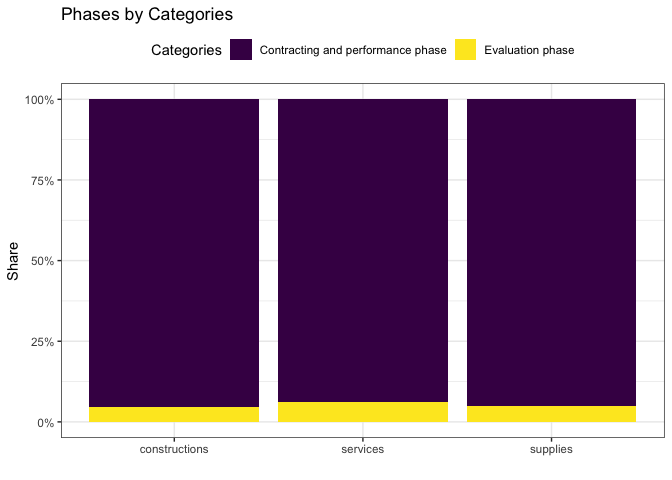

### Distribution of deadline days

Looking at deadline length distribution, I decided to plot a histogram which indicates that the shape is right-skewed and the **average due days are around 21 days for each procurement**. The shaded rectangle presents deadline values which are the extreme values of the distribution.

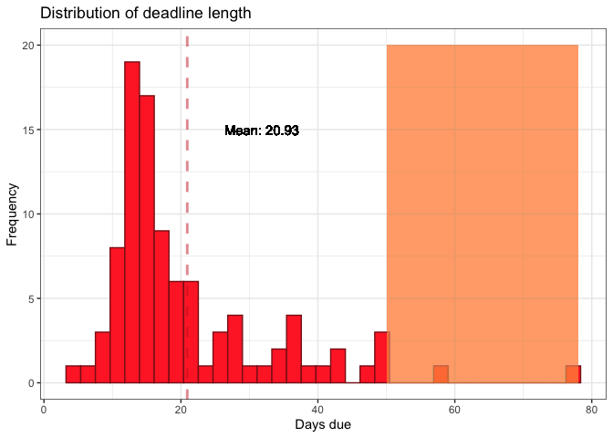

```r
ggplot(df, aes(deadline_length_days)) +
  geom_histogram(colour="firebrick4", fill="firebrick1", bins=35) +
  geom_vline(aes(xintercept=mean(deadline_length_days, na.rm=T)),
             color="firebrick3", linetype="dashed", size=1, alpha = 0.5) +
  geom_text(aes(mean(deadline_length_days, na.rm=T), 15, label=paste0("Mean: ",round(mean(deadline_length_days, na.rm=T), 2))), hjust = -0.5) +
  geom_rect( inherit.aes=FALSE, aes(xmin=50, xmax=max(deadline_length_days, na.rm=T),ymin=0,
                                    ymax=20),  color="transparent", fill="lightsalmon", alpha=0.02) +
  labs(title = 'Distribution of deadline length',
       x = 'Days due',
       y = 'Frequency') +
  theme_bw()
```

### Movement of project values

We can recognize occasional spikes when looking at the change of awarded tender values. **The highest spike was around August and September of 2021 moving beyond the value of 1 billion HUF**. Furthermore, data points indicate that tenders have been more frequently advertised as we move along the time axis.

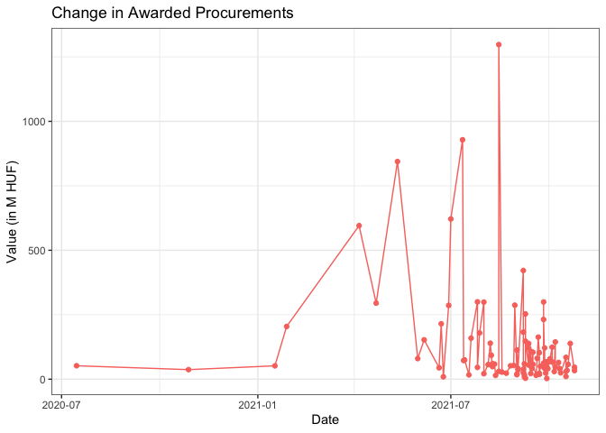

```r
ggplot(df, aes(date, awarded_value_m, color = "firebrick3"))+
  geom_line() +
  geom_point() +
  labs(title = "Change in Awarded Procurements",
       x = "Date",
       y = "Value (in M HUF)") +
  theme_bw() +
  theme(legend.position = "none")
```

### Biggest suppliers on the market

Lastly, I looked at the organizations with the highest totals in terms of tender values. **The most successful procurement company was DRYVIT PROFI construction company** with a whooping total beyond 1 billion HUF in value.

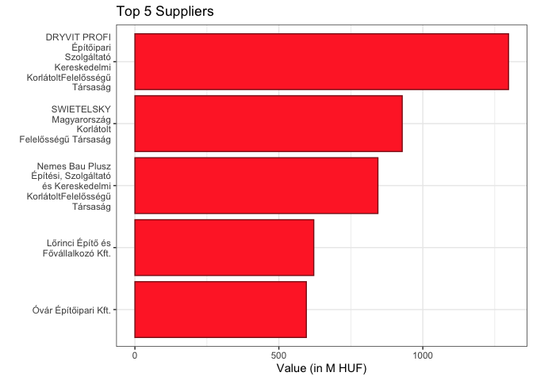

```r
awarded %>%
  group_by(name) %>%
  summarise(total=sum(value_m)) %>%
  arrange(-total) %>%
  slice(c(1:5)) %>%
     ggplot( aes(reorder(stringr::str_wrap(name, 20), total), total)) +
        geom_col(colour="firebrick4", fill="firebrick1") +
        coord_flip() +
        labs(title = "Top 5 Suppliers",
             x = "",
             y = "Value (in M HUF)") +
        theme_bw()
```